# reproducible_research_hw

Alexander Shemetev

24 8 2020

# Part I. The Main Analysis

#Initialize ##################################

Install all the potentially needed packages:

```r
install_and_load = function(name, char = T)
{
  if (!require(name, character.only = char))
  {
    install.packages(name)
  }
  require(name, character.only = char)
}

 #install_github("dgrtwo/broom")
# library(broom)
sapply(
  c("data.table","tidyverse","magrittr", "modelr",
    "arules","arulesViz","readxl","dplyr", "ggplot2", "haven", "expss", "ipumsr", "devtools", "broom",
    "purrr", "GGally", "cluster", "readxl", "tidyr", "writexl", "xlsx", "openxlsx", "psych", 'data.table',
    "readxl", "knitr", "ExPanDaR", "kableExtra", "plm", "sampleSelection", "nnet", "reshape2", "data.table","dplyr","magrittr",
    "lubridate", "scales","norm","RPostgreSQL","tidyr","gganimate","gifski","stringr","tm","readr","textclean","grid","ggpubr","gridExtra","lubridate","writexl","xlsx","RSQLite","odbc","dbplyr","seasonal","plotly","forecast","mFilter","tseries","plm","AER","stargazer","merTools","RColorBrewer","colorRamps"),
  install_and_load
)
```

[output not shown]

```r
rm(install_and_load)
```

### Load the data (i.e. read.csv())

You can do this, for example:

```r
my_path_to_file = "C:\\Users\\Alex\\Documents\\COURSERA STUDIES\\Reproducible Research JHI\\Week_2 PS1\\"
dir(my_path_to_file) #To see if there is the file we need and to check the name of the file
```

```
## [1] "My_Assignment_R.R"               "repdata_data_activity"
## [3] "repdata_data_activity.zip"       "RWO"
## [5] "Variable_Description README.txt"
```

```r
data_on_activities <- read.csv(unz(paste(my_path_to_file, "repdata_data_activity.zip", sep=""),"activity.csv"), header=TRUE, na.strings="NA", sep=",", quote="\"")
# Checking if the file opened OK:
str(data_on_activities) # OK - file is opened OK
```

```
## 'data.frame':    17568 obs. of  3 variables:
##  $ steps   : int  NA NA NA NA NA NA NA NA NA NA ...
##  $ date    : chr  "2012-10-01" "2012-10-01" "2012-10-01" "2012-10-01" ...
##  $ interval: int  0 5 10 15 20 25 30 35 40 45 ...
```

### Process/transform the data (if necessary) into a format suitable for your analysis

```r
typeof(data_on_activities)
```

```
## [1] "list"
```

```r
data_on_activities = data.table(data_on_activities)
class(data_on_activities) #Data table data frame - so it is OK for the future analysis
```

```
## [1] "data.table" "data.frame"
```

```r
## Datet time transformation   $ date    : chr  "2012-10-01" "2012-10-01"
# EPL2011_12$Date2 <- as.Date( as.character(EPL2011_12$Date), "%d-%m-%y")
# library(lubridate)
data_on_activities$date1 <- as.Date( as.character(data_on_activities$date), "%Y-%m-%d")
data_suggested_for_analysis_1 <- data_on_activities[!is.na(data_on_activities$steps),]
```

### Calculate the total number of steps taken per day

```r
total_steps_by_date <- aggregate(data=data_suggested_for_analysis_1,steps~date1,sum) #Done in this line
# View(total_steps_by_date) #We have a small dataset - so it is OK to view it
knitr::kable(head(total_steps_by_date, 10))
```

| date1 | steps |
| --- | --- |
| 2012-10-02 | 126 |
| 2012-10-03 | 11352 |
| 2012-10-04 | 12116 |
| 2012-10-05 | 13294 |
| 2012-10-06 | 15420 |
| 2012-10-07 | 11015 |
| 2012-10-09 | 12811 |
| 2012-10-10 | 9900 |
| 2012-10-11 | 10304 |
| 2012-10-12 | 17382 |

### If you do not understand the difference between a histogram and a barplot, research the difference between them.

### Make a histogram of the total number of steps taken each day

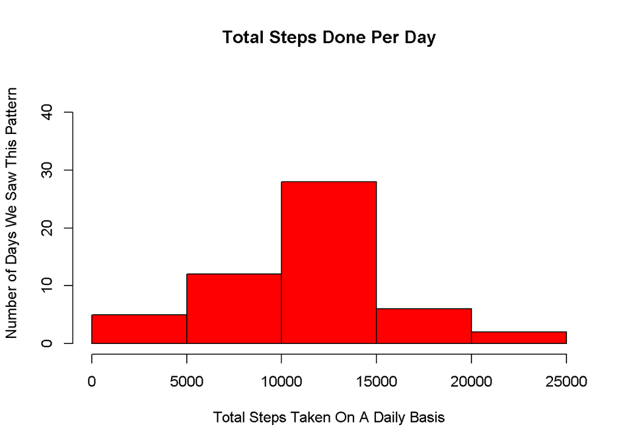

```r
hist1 = hist(total_steps_by_date$steps,
     main="Total Steps Done Per Day",
     xlab="Total Steps Taken On A Daily Basis",
     ylab="Number of Days We Saw This Pattern",
     col="red",
     ylim=range(0:45)) #Cut the OY axis till 45
```

```r
hist1
```

```
## $breaks
## [1]     0  5000 10000 15000 20000 25000
##
## $counts
## [1]  5 12 28  6  2
##
## $density
## [1] 1.886792e-05 4.528302e-05 1.056604e-04 2.264151e-05 7.547170e-06
##
## $mids
## [1]  2500  7500 12500 17500 22500
##
## $xname
## [1] "total_steps_by_date$steps"
##
## $equidist
## [1] TRUE
##
## attr(,"class")
## [1] "histogram"
```

```r
# figure/ directory

png("C:\\Users\\Alex\\Documents\\R\\HOMEPROJECTS\\Reproducible_Research_1\\figure\\directory\\figure_1.png", width=480, height=480)
hist(total_steps_by_date$steps,
     main="Total Steps Done Per Day",
     xlab="Total Steps Taken On A Daily Basis",
     ylab="Number of Days We Saw This Pattern",
     col="red",
     ylim=range(0:45)) #Cut the OY axis till 45
dev.off()
```

### Calculate and report the mean and median of the total number of steps taken per day

```r
### Method 1:
summary(total_steps_by_date) # Done:  Mean and median will be in this output
```

```
##      date1                steps
##  Min.   :2012-10-02   Min.   :   41
##  1st Qu.:2012-10-16   1st Qu.: 8841
##  Median :2012-10-29   Median :10765
##  Mean   :2012-10-30   Mean   :10766
##  3rd Qu.:2012-11-16   3rd Qu.:13294
##  Max.   :2012-11-29   Max.   :21194
```

```r
### Method 2:
require(Hmisc)
Hmisc::describe(total_steps_by_date) #More detailed statistics
```

```
## total_steps_by_date
##
##  2  Variables      53  Observations
## --------------------------------------------------------------------------------
## date1
##          n    missing   distinct       Info       Mean        Gmd        .05
##         53          0         53          1 2012-10-30      20.53 2012-10-04
##        .10        .25        .50        .75        .90        .95
## 2012-10-07 2012-10-16 2012-10-29 2012-11-16 2012-11-23 2012-11-26
##
## lowest : 2012-10-02 2012-10-03 2012-10-04 2012-10-05 2012-10-06
## highest: 2012-11-25 2012-11-26 2012-11-27 2012-11-28 2012-11-29
## --------------------------------------------------------------------------------
## steps
##        n  missing distinct     Info     Mean      Gmd      .05      .10
##       53        0       53        1    10766     4684     2928     5103
##      .25      .50      .75      .90      .95
##     8841    10765    13294    15108    16205
##
## lowest :    41   126  2492  3219  4472, highest: 15414 15420 17382 20427 21194
## --------------------------------------------------------------------------------
```

```r
### Method 3:
mn1 <- round(mean(total_steps_by_date$steps),digits=2)
md1 <- round(median(total_steps_by_date$steps),digits=2)
mn1
```

```
## [1] 10766.19
```

```r
md1
```

```
## [1] 10765
```

**The MEAN steps per day is: 10766.19**

**The MEDIAN steps per day is: 10765**

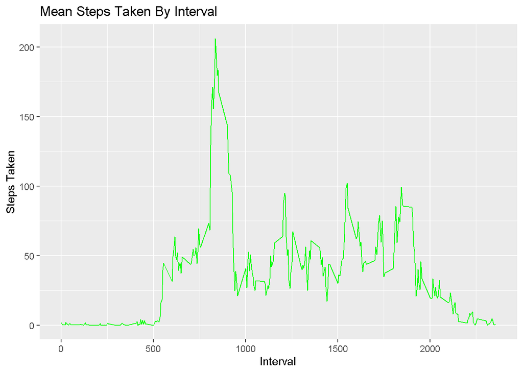

```r
average_steps_by_interval <- aggregate(data=data_suggested_for_analysis_1,steps~interval,mean)
myplot1 = ggplot(average_steps_by_interval, aes(x=interval, y=steps)) +
  geom_line(color="green") +
  xlab("Interval") +
  ylab("Steps Taken") +
  ggtitle("Mean Steps Taken By Interval")
myplot1
```

```r
png("C:\\Users\\Alex\\Documents\\R\\HOMEPROJECTS\\Reproducible_Research_1\\figure\\directory\\figure_2.png", width=480, height=480)
myplot1
dev.off()
```

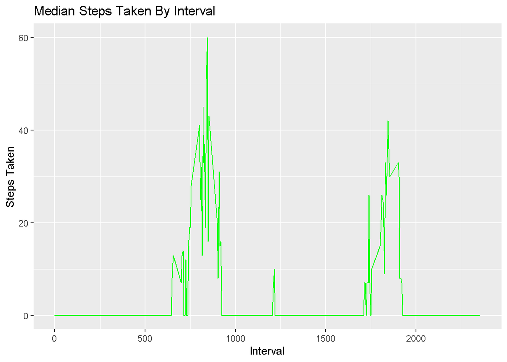

```r
average_steps_by_interval_1 <- aggregate(data=data_suggested_for_analysis_1,steps~interval,median)
myplot2 = ggplot(average_steps_by_interval_1, aes(x=interval, y=steps)) +
  geom_line(color="green") +
  xlab("Interval") +
  ylab("Steps Taken") +
  ggtitle("Median Steps Taken By Interval")
myplot2
```

```r
png("C:\\Users\\Alex\\Documents\\R\\HOMEPROJECTS\\Reproducible_Research_1\\figure\\directory\\figure_3.png", width=480, height=480)
myplot2
dev.off()
```

### Which 5-minute interval, on average across all the days in the dataset, contains the maximum number of steps?

```r
### Method 1:
five_min_interval_Avg_all_days_maximum_N_steps <- average_steps_by_interval[average_steps_by_interval$steps==max(average_steps_by_interval$steps), ]
View(five_min_interval_Avg_all_days_maximum_N_steps) #Second column
summary(five_min_interval_Avg_all_days_maximum_N_steps) #Or all numbers here with the name Interval
```

```
##     interval       steps
##  Min.   :835   Min.   :206.2
##  1st Qu.:835   1st Qu.:206.2
##  Median :835   Median :206.2
##  Mean   :835   Mean   :206.2
##  3rd Qu.:835   3rd Qu.:206.2
##  Max.   :835   Max.   :206.2
```

```r
### Method 2:
summary(average_steps_by_interval) #We see Max.   :206.170
```

```
##     interval          steps
##  Min.   :   0.0   Min.   :  0.000
##  1st Qu.: 588.8   1st Qu.:  2.486
##  Median :1177.5   Median : 34.113
##  Mean   :1177.5   Mean   : 37.383
##  3rd Qu.:1766.2   3rd Qu.: 52.835
##  Max.   :2355.0   Max.   :206.170
```

```r
which(average_steps_by_interval$steps > 206.169) # See the result 104
```

```
## [1] 104
```

```r
average_steps_by_interval$interval[104] #We see the answer
```

```
## [1] 835
```

```r
### Method 3:
which(average_steps_by_interval$steps == max(average_steps_by_interval$steps)) #Returns 104
```

```
## [1] 104
```

```r
average_steps_by_interval$interval[104] #We see the answer
```

```
## [1] 835
```

```r
### Method 4:
v1 = table(average_steps_by_interval$steps == max(average_steps_by_interval$steps), average_steps_by_interval$interval)
v1 = data.table(v1) #Otherwise the next step will be impossible
v2 = v1[v1$V1 == TRUE & v1$N > 0, ] #V1 - T/F variable if maximum => we need it is to be TRUE; N - number of observations where the Maximum value is True (need to be more than 0 - at least once Max value should appear)
str(v2) #We see the Answer: 835
```

```
## Classes 'data.table' and 'data.frame':   1 obs. of  3 variables:
##  $ V1: chr "TRUE"
##  $ V2: chr "835"
##  $ N : int 1
##  - attr(*, ".internal.selfref")=<externalptr>
```

```r
rm(v1) #v2 is small - it doesn't hold any significant place in the PC memory
```

# Part II. Imputing missing values

### Calculate and report the total number of missing values in the dataset (i.e. the total number of rows with NAs)

```r
### Method I
summary(data_on_activities) #The easiest one and the most obvious
```

```
##      steps            date              interval          date1
##  Min.   :  0.00   Length:17568       Min.   :   0.0   Min.   :2012-10-01
##  1st Qu.:  0.00   Class :character   1st Qu.: 588.8   1st Qu.:2012-10-16
##  Median :  0.00   Mode  :character   Median :1177.5   Median :2012-10-31
##  Mean   : 37.38                      Mean   :1177.5   Mean   :2012-10-31
##  3rd Qu.: 12.00                      3rd Qu.:1766.2   3rd Qu.:2012-11-15
##  Max.   :806.00                      Max.   :2355.0   Max.   :2012-11-30
##  NA's   :2304
```

```r
# We see the number of NAs in each solumn
### Method II
my_NA_data <- data_on_activities[is.na(data_on_activities$steps),]
my_NA_data <- count(my_NA_data)
View(my_NA_data)
length(my_NA_data) #Check the Number of columns
```

```
## [1] 1
```

```r
dim(my_NA_data) #Check all NA data Number of observations
```

```
## [1] 1 1
```

```r
### Method III
purrr::map(data_on_activities, ~sum(is.na(.)))
```

```
## $steps
## [1] 2304
##
## $date
## [1] 0
##
## $interval
## [1] 0
##
## $date1
## [1] 0
```

```r
### Method IV
data_on_activities %>%
  dplyr::summarise_all(dplyr::funs(sum(is.na(.))))
```

```
##   steps date interval date1
## 1  2304    0        0     0
```

```r
### Method V
sapply(X = data_on_activities, FUN = function(x) sum(is.na(x)))
```

```
##    steps     date interval    date1
##     2304        0        0        0
```

```r
### Method VI
apply(data_on_activities, 2, function(x) length(which(is.na(x)))) #Longer in computation than the previous one
```

```
##    steps     date interval    date1
##     2304        0        0        0
```

```r
### Method VII
apply(is.na(data_on_activities), 2, sum)
```

```
##    steps     date interval    date1
##     2304        0        0        0
```

```r
### Method VIII
colSums(is.na(data_on_activities))
```

```
##    steps     date interval    date1
##     2304        0        0        0
```

### For example, you could use the mean/median for that day, or the mean for that 5-minute interval, etc.

### Create a new dataset that is equal to the original dataset but with the missing data filled in.

```r
### Method I
summary(data_on_activities) #The easiest one and the most obvious
```

```
##      steps            date              interval          date1
##  Min.   :  0.00   Length:17568       Min.   :   0.0   Min.   :2012-10-01
##  1st Qu.:  0.00   Class :character   1st Qu.: 588.8   1st Qu.:2012-10-16
##  Median :  0.00   Mode  :character   Median :1177.5   Median :2012-10-31
##  Mean   : 37.38                      Mean   :1177.5   Mean   :2012-10-31
##  3rd Qu.: 12.00                      3rd Qu.:1766.2   3rd Qu.:2012-11-15
##  Max.   :806.00                      Max.   :2355.0   Max.   :2012-11-30
##  NA's   :2304
```

```r
# We see the number of NAs in each solumn
### Method II
my_NA_data <- data_on_activities[is.na(data_on_activities$steps),]
my_NA_data <- count(my_NA_data)
View(my_NA_data)
length(my_NA_data) #Check the Number of columns
```

```
## [1] 1
```

```r
dim(my_NA_data) #Check all NA data Number of observations
```

```
## [1] 1 1
```

```r
### Method III
purrr::map(data_on_activities, ~sum(is.na(.)))
```

```
## $steps
## [1] 2304
##
## $date
## [1] 0
##
## $interval
## [1] 0
##
## $date1
## [1] 0
```

```r
### Method IV
data_on_activities %>%
  dplyr::summarise_all(dplyr::funs(sum(is.na(.))))
```

```
##   steps date interval date1
## 1  2304    0        0     0
```

```r
### Method V
sapply(X = data_on_activities, FUN = function(x) sum(is.na(x)))
```

```
##    steps     date interval    date1
##     2304        0        0        0
```

```r
### Method VI
apply(data_on_activities, 2, function(x) length(which(is.na(x)))) #Longer in computation than the previous one
```

```
##    steps     date interval    date1
##     2304        0        0        0
```

```r
### Method VII
apply(is.na(data_on_activities), 2, sum)
```

```
##    steps     date interval    date1
##     2304        0        0        0
```

```r
### Method VIII
colSums(is.na(data_on_activities))
```

```
##    steps     date interval    date1
##     2304        0        0        0
```

### Make a histogram of the total number of steps taken each day and Calculate and report the mean and median total number of steps taken per day.

### Do these values differ from the estimates from the first part of the assignment?

### What is the impact of imputing missing data on the estimates of the total daily number of steps?

```r
remade_to_df_data_on_activities <- dplyr::tbl_df(data_on_activities)
```

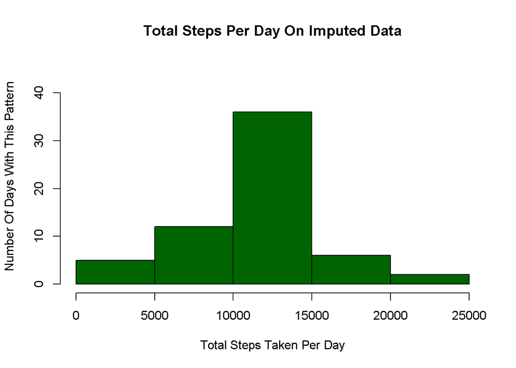

```r
# average_steps_by_interval <- aggregate(data=data_suggested_for_analysis_1,steps~interval,mean)
remade_to_df_data_on_activities <- inner_join(remade_to_df_data_on_activities, average_steps_by_interval, by = "interval")
# names(remade_to_df_data_on_activities) <- c("steps","date","interval","avg", "date1")
remade_to_df_data_on_activities$steps <- ifelse(is.na(remade_to_df_data_on_activities$steps.x), remade_to_df_data_on_activities$steps.y, remade_to_df_data_on_activities$steps.x)

imputed_aggregated_data_steps_per_day <- aggregate(data=remade_to_df_data_on_activities,steps~date,sum)

hist2 = hist(imputed_aggregated_data_steps_per_day$steps,
     main="Total Steps Per Day On Imputed Data",
     xlab="Total Steps Taken Per Day",
     ylab="Number Of Days With This Pattern",
     col="darkgreen",
     ylim=range(0:45))
```

```r
hist2
```

```
## $breaks
## [1]     0  5000 10000 15000 20000 25000
##
## $counts
## [1]  5 12 36  6  2
##
## $density
## [1] 1.639344e-05 3.934426e-05 1.180328e-04 1.967213e-05 6.557377e-06
##
## $mids
## [1]  2500  7500 12500 17500 22500
##
## $xname
## [1] "imputed_aggregated_data_steps_per_day$steps"
##
## $equidist
## [1] TRUE
##
## attr(,"class")
## [1] "histogram"
```

```r
png("C:\\Users\\Alex\\Documents\\R\\HOMEPROJECTS\\Reproducible_Research_1\\figure\\directory\\figure_4.png", width=480, height=480)
hist(imputed_aggregated_data_steps_per_day$steps,
     main="Total Steps Per Day On Imputed Data",
     xlab="Total Steps Taken Per Day",
     ylab="Number Of Days With This Pattern",
     col="darkgreen",
     ylim=range(0:45))
dev.off()
```

```r
summary(imputed_aggregated_data_steps_per_day$steps) #There is mean and median
```

```
##    Min. 1st Qu.  Median    Mean 3rd Qu.    Max.
##      41    9819   10766   10766   12811   21194
```

```r
# Another way:
mn_2 <- round(mean(imputed_aggregated_data_steps_per_day$steps),digits=2)
md_2 <- round(median(imputed_aggregated_data_steps_per_day$steps),digits=2)
mn_2
```

```
## [1] 10766.19
```

```r
md_2
```

```
## [1] 10766.19
```

```r
### Differences from the first part of the assignment:
mn1
```

```
## [1] 10766.19
```

```r
md1
```

```
## [1] 10765
```

```r
diff_mean = mn1 - mn_2
diff_median = md1 - md_2
diff_mean #Mean is the same
```

```
## [1] 0
```

```r
diff_median #Median is a bit different (-1.19)
```

```
## [1] -1.19
```

```r
# Other ways for doing same are made above (for the non-imputed data)
```

**The difference in the MEAN steps per day with imputed data is: 0** **The difference in the MEDIAN steps per day with imputed data is: -1.19000000000051**

# Part II. Are there differences in activity patterns between weekdays and weekends?

```r
system("defaults write org.R-project.R force.LANG en_US.UTF-8")
```

```
## [1] 127
```

```r
Sys.setlocale("LC_ALL","English") #to be sure the names in the DS will be in English
```

```
## [1] "LC_COLLATE=English_United States.1252;LC_CTYPE=English_United States.1252;LC_MONETARY=English_United States.1252;LC_NUMERIC=C;LC_TIME=English_United States.1252"
```

```r
remade_to_df_data_on_activities_3 <- data.frame(remade_to_df_data_on_activities, dow = weekdays(as.Date(remade_to_df_data_on_activities$date)))
remade_to_df_data_on_activities_3$dow <- as.factor(remade_to_df_data_on_activities_3$dow)
summary(remade_to_df_data_on_activities_3$dow)
```

```
##    Friday    Monday  Saturday    Sunday  Thursday   Tuesday Wednesday
##      2592      2592      2304      2304      2592      2592      2592
```

```r
remade_to_df_data_on_activities_3$dow_w_nd <- ifelse(remade_to_df_data_on_activities_3$dow %in% c("Sunday","Saturday"), "weekend","weekday")
### Other method:
remade_to_df_data_on_activities_3 <- mutate(remade_to_df_data_on_activities_3, dow_cat = ifelse(remade_to_df_data_on_activities_3$dow %in% c("Sunday","Saturday"), "weekend","weekday"))
remade_to_df_data_on_activities_3$dow_cat <- as.factor(remade_to_df_data_on_activities_3$dow_cat)
remade_to_df_data_on_activities_3$interval <- as.factor(remade_to_df_data_on_activities_3$interval)
```

### Make a panel plot containing a time series plot (i.e. type = “l”) of the 5-minute interval (x-axis) and the average number of steps taken, averaged across all weekday days or weekend days (y-axis). See the README file in the GitHub repository to see an example of what this plot should look like using simulated data.

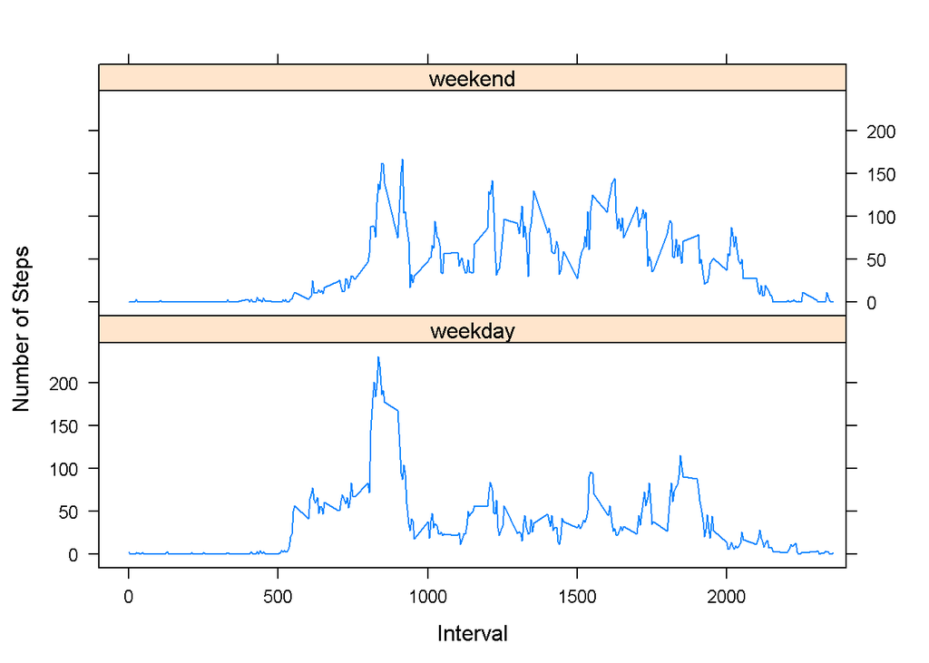

```r
weekend_vs_weekdays_steps_intevals <- aggregate(data=remade_to_df_data_on_activities_3,steps~dow_cat+interval,mean)
weekend_vs_weekdays_steps_intevals$interval <- as.character(weekend_vs_weekdays_steps_intevals$interval)

final_plot = xyplot(steps~interval|factor(dow_cat),
       data = weekend_vs_weekdays_steps_intevals,
       type='l',
       layout=c(1,2),
       xlab='Interval',
       ylab='Number of Steps',
       # OX = from -100 to 2500; bin size 500 (step on the chart)
       xlim=seq(-100,2500,500)) #The plot is the copy of the plot requested in the task
final_plot
```

```r
png("C:\\Users\\Alex\\Documents\\R\\HOMEPROJECTS\\Reproducible_Research_1\\figure\\directory\\figure_5.png", width=480, height=480)
final_plot
dev.off()
```